# Lab 4, Sam Quist

```python
%matplotlib inline
import numpy as np
import matplotlib
import matplotlib.pyplot as plt
import scipy
from scipy import stats
```

# 1.

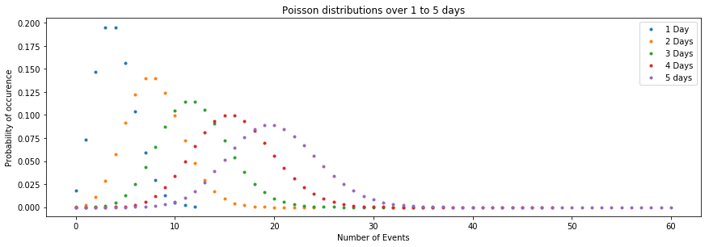

```python
# 1A
plt.subplots_adjust(top=2,right=2)
x = 4
y = 6
fig1 = plt.figure(1)
occur = np.linspace(0,12,13)
plt.subplot(2,1,1)
plt.title('Poisson distributions over 1 to 5 days')
plt.plot(occur, stats.poisson.pmf(occur,x),'.',label='1 Day');
backg = stats.poisson.pmf(occur,x)

twodays = np.convolve(backg,backg)
x2 = np.linspace(0,24,25)
plt.plot(x2,twodays,'.',label='2 Days')

th3days = np.convolve(twodays,backg)
x3 = np.linspace(0,36,37)
plt.plot(x3,th3days,'.',label='3 Days')

f4days = np.convolve(th3days,backg)
x4 = np.linspace(0,48,49)
plt.plot(x4,f4days,'.',label='4 Days')

f5days = np.convolve(f4days,backg)
x5 = np.linspace(0,60,61)
plt.plot(x5,f5days,'.',label='5 days');
plt.ylabel('Probability of occurence')
plt.xlabel('Number of Events')
plt.legend();
```

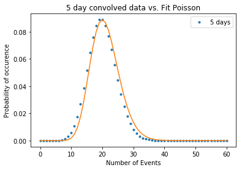

```python
# 1B
f5days = np.convolve(f4days,backg)
x5 = np.linspace(0,60,61)
plt.plot(x5,f5days,'.',label='5 days');
plt.legend()
xp = 20
oc5 = np.linspace(0,60,61)
fit = stats.poisson.pmf(xp,oc5)
plt.plot(oc5,fit);
plt.ylabel('Probability of occurence')
plt.xlabel('Number of Events')
plt.title('5 day convolved data vs. Fit Poisson');
```

The fitted poisson curve with the expected average from convolution matches up with the 5 day convolved data since the convolving pdfs both are poisson distribution types.

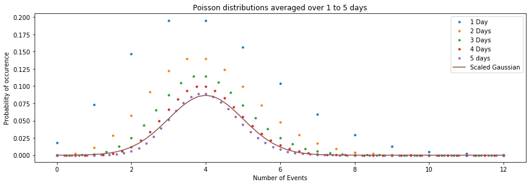

```python
# 1C
plt.subplots_adjust(top=2,right=2)
fig1 = plt.figure(1)
occur = np.linspace(0,12,13)
plt.subplot(2,1,1)
plt.title('Poisson distributions averaged over 1 to 5 days')
plt.plot(occur, stats.poisson.pmf(occur,x),'.',label='1 Day');
backg = stats.poisson.pmf(occur,x)

twodays = np.convolve(backg,backg)
x2 = np.linspace(0,24,25)/2
plt.plot(x2,twodays,'.',label='2 Days')

th3days = np.convolve(twodays,backg)
x3 = np.linspace(0,36,37)/3
plt.plot(x3,th3days,'.',label='3 Days')

f4days = np.convolve(th3days,backg)
x4 = np.linspace(0,48,49)/4
plt.plot(x4,f4days,'.',label='4 Days')

f5days = np.convolve(f4days,backg)
x5 = np.linspace(0,60,61)/5
plt.plot(x5,f5days,'.',label='5 days');
plt.ylabel('Probability of occurence')
plt.xlabel('Number of Events')
gaus = stats.norm.pdf(x5,x,1)
plt.plot(x5,gaus/4.6,label='Scaled Gaussian')
plt.legend();
```

The shape of the distribution approaches a gaussian shape, which is due to the central limit theorem. This is due to the normalized distribution being made up of independently random variables. This does not happen in 1B since the convolved pdfs are not normalized.

```python
# 1D
# N = 4, so Y*N = 24
# Lambda = 4*N = 16
p_36 = 1-stats.poisson.cdf(24,16)
print(p_36)
Z = abs(stats.norm.ppf(p_36))
print(Z)
sigma = (24-16)/Z
print(sigma)
```

```
0.02231547798196587
2.0081160983716853
3.983833408081801
```

# 2.

```python
# Gamma Distribution
```

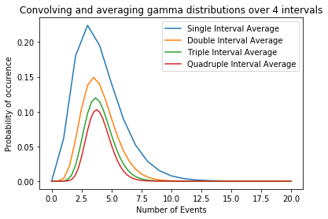

```python
# interval of 1 day
x = 4 # avg background emissions per interval
y = 6 # avg source emissions per interval
xvals = np.linspace(0,20,21)
dist = stats.gamma.pdf(xvals,4)
plt.plot(xvals,dist,label='Single Interval Average');
dist2 = np.convolve(dist,dist)
vals2 = np.linspace(0,40,41)/2
plt.plot(vals2,dist2,label='Double Interval Average')
dist3 = np.convolve(dist2,dist)
vals3 = np.linspace(0,60,61)/3
plt.plot(vals3,dist3,label='Triple Interval Average')
dist4 = np.convolve(dist3,dist)
vals4 = np.linspace(0,80,81)/4
plt.plot(vals4,dist4,label='Quadruple Interval Average')

plt.ylabel('Probability of occurence')
plt.xlabel('Number of Events')
plt.title('Convolving and averaging gamma distributions over 4 intervals')

plt.legend();
# Seems to follow gaussian distribution around 4 averaged intervals
# 234 intervals dont integrate to 1 since they have been averaged
```

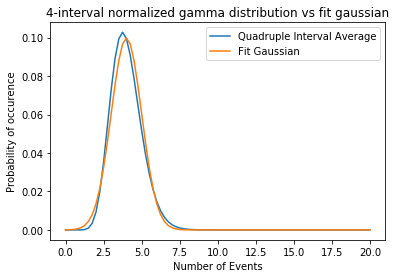

```python
dist4 = np.convolve(dist3,dist)
vals4 = np.linspace(0,80,81)/4
plt.plot(vals4,dist4,label='Quadruple Interval Average')


plt.ylabel('Probability of occurence')
plt.xlabel('Number of Events')
gaussfit = stats.norm.pdf(vals4,x,1)
plt.plot(vals4,gaussfit/4,label='Fit Gaussian')
plt.title('4-interval normalized gamma distribution vs fit gaussian')
plt.legend();
```

The shape changes and approaches a gaussian shape. This is similar to problem 1, where after convolving and normalizing the distributions, they approach a gaussian shape. The convolved gamma distribution is essentially a gaussian after 4 intervals.

# 3.

```
Sigma: 5.539999999413368
Probability of getting false data that says there is a signal: 1.512358238642264e-08
```

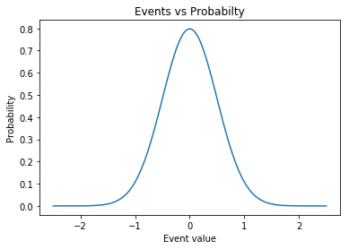

```python
# Version 1
sigma = .5 # Standard Deviation
X = 2.35482*np.sqrt(sigma) # Background gaussian width
bvals = np.linspace(-2.5,2.5,1000)
background = stats.norm.pdf(bvals,0,sigma)
plt.plot(bvals,background)
Y = 2.77 # Detection value
probY = 1-stats.norm.cdf(Y,0,sigma)
fivesigma = stats.norm.ppf(1-probY)
print('Sigma: '+ str(fivesigma))
# Signal is significant, more than 5 sigma away (5.54)
print('Probability of getting false data that says there is a signal: ' + str(probY))
plt.xlabel('Event value')
plt.ylabel('Probability')
plt.title('Events vs Probabilty');
```

```python
# Version 2
# If the probability off of one cell is probY, then over 10k pixels it would be
prob10k = probY * 10000
print(prob10k)
# Statistical Question: what is prob that meas is Y or higher over 10k CCDs?
# math is 10000(1-cdf(Y))
```

```
0.0001512358238642264
```

```python
# Significance is sigma value, which is ppf(1-percentage value * 10000)
sig10k = stats.norm.ppf(1-prob10k)
# sigma value from z-table based on classic gaussian
print('The significance of the measurement is '+str(sig10k)+' sigma')
```

```
The significance of the measurement is 3.6131739410205315 sigma
```

# 4.

```python
# 4A
# Using the earlier distribution with sigma=.5,
# A 5 sigma detection would be exactly 5*.5, or 2.5 brightness value
```

```python
# 4B
# Since the overall distribution changes, we have to recalculate the sigma value
# 5 sigma is orignally 1/3500000, but with 10k ccds it is now 1/3500000 * (1/10000)
prob5sigma = 1/(3.5*10**6)
meas_10k = stats.norm.ppf(1-prob5sigma/10000,0,.5)
print(meas_10k)
```

```
3.275513197025793
```

```python
# 4C
```

The signal must be around .77 values brighter for a trials factor of 10k, which isnt that much considering if a single 5 sigma event has a false occurence of 1/3.5 million, the 5 sigma event for a false occurence would be 1/(3.5 million *10000) or whatever the trials factor is. Applying this to the classic distribution gives a large signal value with a tiny chance to occur falsly.

```python
# 4D
# The change for large orders of magnitude trials factors is easily seen by:
meas_mag = stats.norm.ppf(1-prob5sigma/100000000,0,.5)
print(meas_mag)
```

```
3.904403748459095
```

The trials factor increased by an order(N^4) and the 5 sigma detection threshold increased by about .63, which is a small change for the large order increase.